# 154HW4

Jiyoon Clover Jeong

10/11/2017

```r
library(ElemStatLearn)
library(glmnet)
library(leaps)
library(pls)
library(caret)
```

# Problem 1 (10 pts)

$$r_{1,4} = \frac{cov(X1, X4)}{SD(X1)SD(X4)}$$
and cov(X1, X4) = cov(X1, X1 + X2 + X3) = cov(X1, X1) + cov(X1, X2) + cov(X1, X3) = var(X1) + 0 + 0 = var(X1) = $\sigma_{1}^2$

var(X4) = var(X1 + X2 + X3) = var(X1) + var(X2) + var(X3) = $\sigma_{1}^2$ + $\sigma_{1}^2$ + $\sigma_{1}^2$ = 3$\sigma_{1}^2$

Therefore,
$$r_{1,4} = \frac{\sigma_{1}^2}{\sqrt{\sigma_{1}^2 * 3\sigma_{1}^2}} = 1/\sqrt{3} = 0.5773503$$

$$r_{2,4} = \frac{cov(X2, X4)}{SD(X2)SD(X4)}$$

and cov(X2, X4) = cov(X2, X1 + X2 + X3) = cov(X2, X1) + cov(X2, X2) + cov(X2, X3) = var(X2) = $\sigma_{1}^2$

var(X4) = var(X1 + X2 + X3) = var(X1) + var(X2) + var(X3) = $\sigma_{1}^2$ + $\sigma_{1}^2$ + $\sigma_{1}^2$ = 3$\sigma_{1}^2$

Therefore,
$$r_{2,4} = \frac{\sigma_{1}^2}{\sqrt{\sigma_{1}^2 * 3\sigma_{1}^2}} = 1/\sqrt{3} = 0.5773503$$

$$r_{3,4} = \frac{cov(X3, X4)}{SD(X3)SD(X4)}$$

and cov(X3, X4) = cov(X3, X1 + X2 + X3) = cov(X3, X1) + cov(X3, X2) + cov(X3, X3) = var(X3) = $\sigma_{1}^2$

var(X4) = var(X1 + X2 + X3) = var(X1) + var(X2) + var(X3) = $\sigma_{1}^2$ + $\sigma_{1}^2$ + $\sigma_{1}^2$ = 3$\sigma_{1}^2$

Therefore,
$$r_{3,4} = \frac{\sigma_{1}^2}{\sqrt{\sigma_{1}^2 * 3\sigma_{1}^2}} = 1/\sqrt{3} = 0.5773503$$

# Problem 2

Show that any two components
$$z_h^Tz_l = 0$$
for
$$(h \neq l)$$
are indeed orthogonal.

** Base Case (i+1) **

$z_i^Tz_{i+1}$ = $z_i^T(\frac{X_iw_{i+1}}{w_{i+1}^Tw_{i+1}})$ = $\frac{1}{w_{i+1}^Tw_{i+1}}z_i^T(X_iw_{i+1})$. ——–> $z_i^T(X_iw_{i+1})$ = 0.

And, $z_i^T(X_iw_{i+1})$ = $z_i^T([x_{i-1}\ -\ z_ip_i^T]w_{i+1})$ = $z_i^T([x_{i-1}\ -\ z_i[\frac{x_{i-1}^Tz_i}{z_i^Tz_i}]^T]w_{i+1})$ = $(z_i^Tx_{i-1}\ -\ z_i^Tx_{i-1})w_{i+1}$ = 0.

$\\$

** Recursion (i+2) **

$z_i^Tz_{i+2}$ = $z_i^T(X_{i+1}w_{i+2})\frac{1}{w_{i+2}^Tw_{i+2}}$ = $z_i^T(X_i\ -\ z_{i+1}p_{i+1}^T)\frac{w_{i+2}}{w_{i+2}^Tw_{i+2}}$ = $(z_i^TX_i\ -\ z_i^Tz_{i+1}p_{i+1}^T)\frac{w_{i+2}}{w_{i+2}^Tw_{i+2}}$.

$z_i^Tz_{i+1}$ = 0 as we proved in the Base case.

$(z_i^TX_i\ -\ z_i^Tz_{i+1}p_{i+1}^T)\frac{w_{i+2}}{w_{i+2}^Tw_{i+2}}$ = $z_i^TX_i\frac{w_{i+2}}{w_{i+2}^Tw_{i+2}}$.

—-> Show $z_i^TX_i$ = 0.

$z_i^TX_i$ = $z_i^T(X_{i-1}\ -\ z_ip_i^T)$ = $z_i^T(X_{i-1}\ -\ z_i[\frac{x_{i-1}^Tz_i}{z_i^Tz_i}]^T)$ = $z_i^TX_{i-1}\ -\ z_i^TX_{i-1}$ = 0.

——–> $z_i^Tz_{i+2}$ = 0

Proof finished.

# Problem 3

```r
length(names(prostate))
```

```
## [1] 10
```

```r
names(prostate)
```

```
##  [1] "lcavol"  "lweight" "age"     "lbph"    "svi"     "lcp"     "gleason"
##  [8] "pgg45"   "lpsa"    "train"
```

```r
train <- prostate[prostate$train == "TRUE", -10 ]

test <- prostate[prostate$train == "FALSE", -10 ]
```

## Correlations of predictors, and some preprocessing (10 pts)

```r
cor(train[,-9])
```

```
##             lcavol    lweight       age        lbph        svi         lcp
## lcavol  1.00000000 0.30023199 0.2863243  0.06316772  0.5929491  0.69204308
## lweight 0.30023199 1.00000000 0.3167235  0.43704154  0.1810545  0.15682859
## age     0.28632427 0.31672347 1.0000000  0.28734645  0.1289023  0.17295140
## lbph    0.06316772 0.43704154 0.2873464  1.00000000 -0.1391468 -0.08853456
## svi     0.59294913 0.18105448 0.1289023 -0.13914680  1.0000000  0.67124021
## lcp     0.69204308 0.15682859 0.1729514 -0.08853456  0.6712402  1.00000000
## gleason 0.42641407 0.02355821 0.3659151  0.03299215  0.3068754  0.47643684
## pgg45   0.48316136 0.07416632 0.2758057 -0.03040382  0.4813577  0.66253335
##            gleason       pgg45
## lcavol  0.42641407  0.48316136
## lweight 0.02355821  0.07416632
## age     0.36591512  0.27580573
## lbph    0.03299215 -0.03040382
## svi     0.30687537  0.48135774
## lcp     0.47643684  0.66253335
## gleason 1.00000000  0.75705650
## pgg45   0.75705650  1.00000000
```

```r
train_stan <- scale(train[,-9])
```

```r
summary(train_stan)
```

```
##      lcavol           lweight              age
##  Min.   :-2.1411   Min.   :-2.62526   Min.   :-3.16524
##  1st Qu.:-0.6641   1st Qu.:-0.62054   1st Qu.:-0.49935
##  Median : 0.1242   Median :-0.05755   Median : 0.03382
##  Mean   : 0.0000   Mean   : 0.00000   Mean   : 0.00000
##  3rd Qu.: 0.8334   3rd Qu.: 0.54029   3rd Qu.: 0.56700
##  Max.   : 2.0180   Max.   : 2.42189   Max.   : 1.89994
##       lbph               svi               lcp             gleason
##  Min.   :-0.99595   Min.   :-0.5331   Min.   :-0.8368   Min.   :-1.032
##  1st Qu.:-0.99595   1st Qu.:-0.5331   1st Qu.:-0.8368   1st Qu.:-1.032
##  Median :-0.08385   Median :-0.5331   Median :-0.4171   Median : 0.379
##  Mean   : 0.00000   Mean   : 0.0000   Mean   : 0.0000   Mean   : 0.000
##  3rd Qu.: 1.00848   3rd Qu.:-0.5331   3rd Qu.: 0.8631   3rd Qu.: 0.379
##  Max.   : 1.54057   Max.   : 1.8480   Max.   : 2.0496   Max.   : 3.200
##      pgg45
##  Min.   :-0.8965
##  1st Qu.:-0.8965
##  Median :-0.3846
##  Mean   : 0.0000
##  3rd Qu.: 0.8099
##  Max.   : 2.5163
```

## Least Squares Model (10 pts)

```r
train_stan <- as.data.frame(cbind(train_stan, lpsa = train$lpsa))

lsfit <- lm(lpsa ~., data = train_stan)
summary(lsfit)$coefficients[,1:3]
```

```
##                Estimate Std. Error    t value
## (Intercept)  2.45234509 0.08701959 28.1815274
## lcavol       0.71640701 0.13350135  5.3662905
## lweight      0.29264240 0.10638488  2.7507894
## age         -0.14254963 0.10211957 -1.3959090
## lbph         0.21200760 0.10312428  2.0558456
## svi          0.30961953 0.12538985  2.4692552
## lcp         -0.28900562 0.15480404 -1.8669126
## gleason     -0.02091352 0.14257805 -0.1466812
## pgg45        0.27734595 0.15959237  1.7378397
```

## Best Subset Regression (10 pts)

```r
subset <- regsubsets(lpsa ~., data = train_stan)
coef(subset, 1:3)
```

```
## [[1]]
## (Intercept)      lcavol
##   2.4523451   0.8855136
##
## [[2]]
## (Intercept)      lcavol     lweight
##   2.4523451   0.7798589   0.3519101
##
## [[3]]
## (Intercept)      lcavol     lweight         svi
##   2.4523451   0.6461297   0.3511573   0.2259134
```

```r
summary(subset)
```

```
## Subset selection object
## Call: regsubsets.formula(lpsa ~ ., data = train_stan)
## 8 Variables  (and intercept)
##         Forced in Forced out
## lcavol      FALSE      FALSE
## lweight     FALSE      FALSE
## age         FALSE      FALSE
## lbph        FALSE      FALSE
## svi         FALSE      FALSE
## lcp         FALSE      FALSE
## gleason     FALSE      FALSE
## pgg45       FALSE      FALSE
## 1 subsets of each size up to 8
## Selection Algorithm: exhaustive
##          lcavol lweight age lbph svi lcp gleason pgg45
## 1  ( 1 ) "*"    " "     " " " "  " " " " " "     " "
## 2  ( 1 ) "*"    "*"     " " " "  " " " " " "     " "
## 3  ( 1 ) "*"    "*"     " " " "  "*" " " " "     " "
## 4  ( 1 ) "*"    "*"     " " "*"  "*" " " " "     " "
## 5  ( 1 ) "*"    "*"     " " "*"  "*" " " " "     "*"
## 6  ( 1 ) "*"    "*"     " " "*"  "*" "*" " "     "*"
## 7  ( 1 ) "*"    "*"     "*" "*"  "*" "*" " "     "*"
## 8  ( 1 ) "*"    "*"     "*" "*"  "*" "*" "*"     "*"
```

```r
# Best number of subset



minsubset <- which.min(summary(subset)$bic)
cat("The best number of subset is ", minsubset, "\n")
```

```
## The best number of subset is  2
```

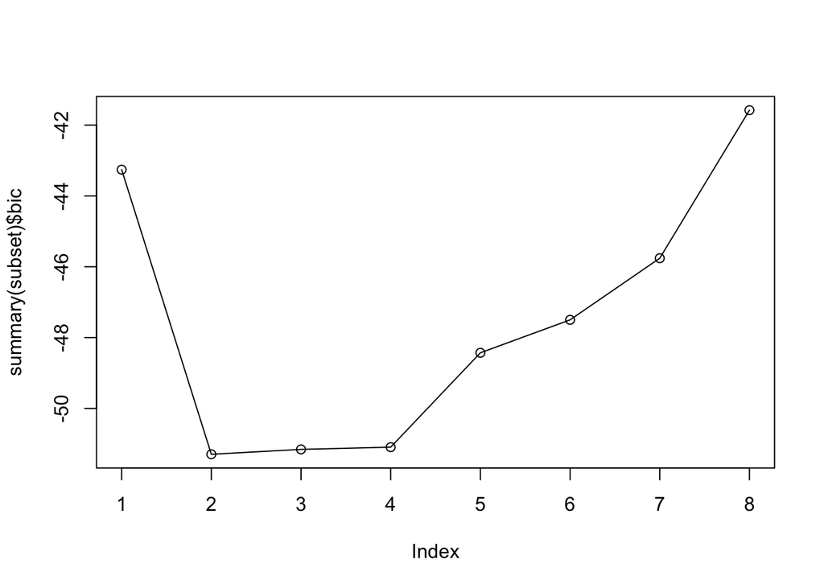

```r
plot(summary(subset)$bic, type = "o")
```

## PCR and PLSR (40 pts)

```r
set.seed(10)

pcr_model <- pcr(lpsa~., data = train_stan, validation = "CV")

# how to change number of folds in validation?

which.min(pcr_model$validation$PRESS)
```

```
## [1] 8
```

```r
summary(pcr_model)
```

```
## Data:    X dimension: 67 8
##  Y dimension: 67 1
## Fit method: svdpc
## Number of components considered: 8
##
## VALIDATION: RMSEP
## Cross-validated using 10 random segments.
##        (Intercept)  1 comps  2 comps  3 comps  4 comps  5 comps  6 comps
## CV           1.217   0.9172   0.8975   0.8372   0.8323   0.8485   0.8467
## adjCV        1.217   0.9141   0.8949   0.8330   0.8269   0.8431   0.8419
##        7 comps  8 comps
## CV      0.8066   0.7833
## adjCV   0.8012   0.7767
##
## TRAINING: % variance explained
##       1 comps  2 comps  3 comps  4 comps  5 comps  6 comps  7 comps
## X       42.83    63.24    76.20    83.92    89.61    94.32    97.82
## lpsa    45.18    50.84    59.58    61.00    61.17    62.08    66.36
##       8 comps
## X      100.00
## lpsa    69.44
```

```r
# Model fits with the smallest CV-MSE of
cat("PCR Tuning parameter : ", which.min(pcr_model$validation$PRESS))
```

```
## PCR Tuning parameter :  8
```

```r
print("Associated coefficients : ")
```

```
## [1] "Associated coefficients : "
```

```r
pcr_model$coefficients[, , which.min(pcr_model$validation$PRESS)]
```

```
##      lcavol     lweight         age        lbph         svi         lcp
##  0.71640701  0.29264240 -0.14254963  0.21200760  0.30961953 -0.28900562
##     gleason       pgg45
## -0.02091352  0.27734595
```

```r
plsr_model <- plsr(lpsa~., data = train_stan, validation = "CV")
summary(plsr_model)
```

```
## Data:    X dimension: 67 8
##  Y dimension: 67 1
## Fit method: kernelpls
## Number of components considered: 8
##
## VALIDATION: RMSEP
## Cross-validated using 10 random segments.
##        (Intercept)  1 comps  2 comps  3 comps  4 comps  5 comps  6 comps
## CV           1.217   0.8475   0.7885   0.7709   0.7616   0.7530   0.7524
## adjCV        1.217   0.8453   0.7844   0.7667   0.7559   0.7482   0.7476
##        7 comps  8 comps
## CV      0.7520   0.7521
## adjCV   0.7473   0.7474
##
## TRAINING: % variance explained
##       1 comps  2 comps  3 comps  4 comps  5 comps  6 comps  7 comps
## X       41.64    58.29    71.13    79.75    86.08    90.21    94.70
## lpsa    55.79    64.60    67.51    69.12    69.37    69.43    69.44
##       8 comps
## X      100.00
## lpsa    69.44
```

```r
plsr_model
```

```
## Partial least squares regression , fitted with the kernel algorithm.
## Cross-validated using 10 random segments.
## Call:
## plsr(formula = lpsa ~ ., data = train_stan, validation = "CV")
```

```r
# Model fits with the smallest CV-MSE of

# Q  how to get CV table from summary???

# CV MSE :  MSEP(pcr_model)

cat("Plsr Tuning parameter : ", which.min(plsr_model$validation$PRESS))
```

```
## Plsr Tuning parameter :  7
```

```r
print("Associated coefficients : ")
```

```
## [1] "Associated coefficients : "
```

```r
plsr_model$coefficients[, , which.min(plsr_model$validation$PRESS)]
```

```
##      lcavol     lweight         age        lbph         svi         lcp
##  0.71636186  0.29192059 -0.14233890  0.21259719  0.31026935 -0.28905136
##     gleason       pgg45
## -0.02101011  0.27706347
```

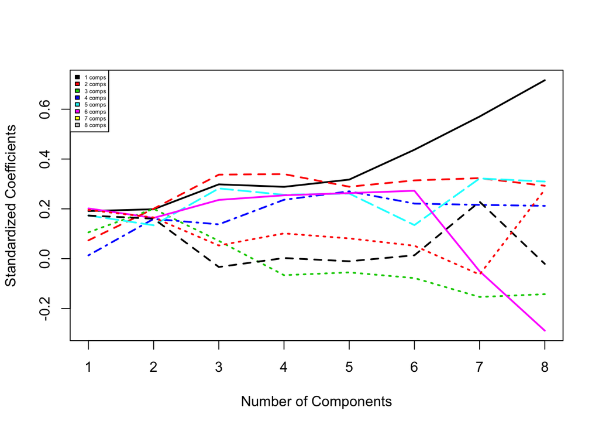

```r
# fit = glmnet(as.matrix(train_stan[,-9]), train_stan$lpsa)
# plot(fit)


# Standardized coefficients??

#  Q   is this plot correct  --- >standardized coefficients ???


# coefplot(pcr_model, ncomp = 1:8, legendpos = "bottomright", xlab = "number of components")
# plot(pcr_model, plottype = "coefficients", ncomp = 1:8)

pcr_coefs = apply(pcr_model$coefficients, 3, function(x) x)

matplot(t(pcr_coefs), type= 'l', lwd = 2, xlab = "Number of Components", ylab = "Standardized Coefficients")
legend("topleft", colnames(pcr_coefs),col=seq_len(ncol(pcr_coefs)),cex=0.4,fill=seq_len(ncol(pcr_coefs)))
```

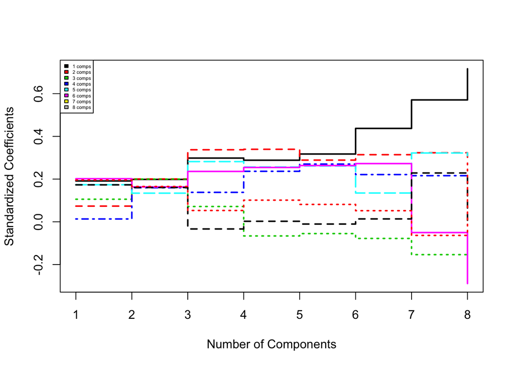

```r
matplot(t(pcr_coefs), type= 's', lwd = 2, xlab = "Number of Components", ylab = "Standardized Coefficients")
legend("topleft", colnames(pcr_coefs),col=seq_len(ncol(pcr_coefs)),cex=0.4,fill=seq_len(ncol(pcr_coefs)))
```

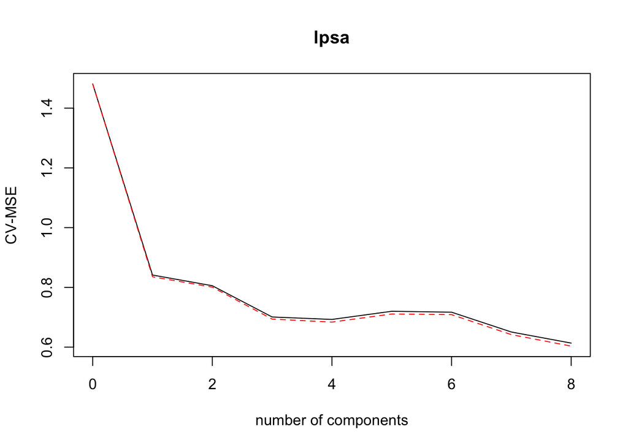

```r
validationplot(pcr_model, val.type = "MSEP", ylab = "CV-MSE")
```

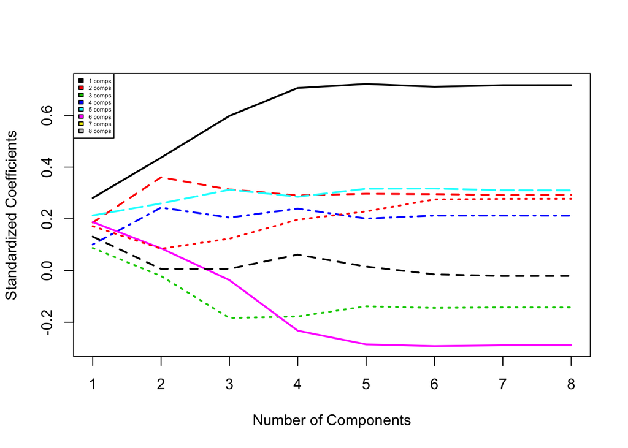

```r
#plot(pcr_model$validation$PRESS[1,], type = "o", main = "PCR")


# coefplot(plsr_model, ncomp = 1:8, legendpos = "bottomright")
# plot(plsr_model, plottype = "coefficients", ncomp = 1:8)


plsr_coefs = apply(plsr_model$coefficients, 3, function(x) x)

matplot(t(plsr_coefs), type= 'l', lwd = 2, xlab = "Number of Components", ylab = "Standardized Coefficients")
legend("topleft", colnames(plsr_coefs),col=seq_len(ncol(plsr_coefs)),cex=0.4,fill=seq_len(ncol(plsr_coefs)))
```

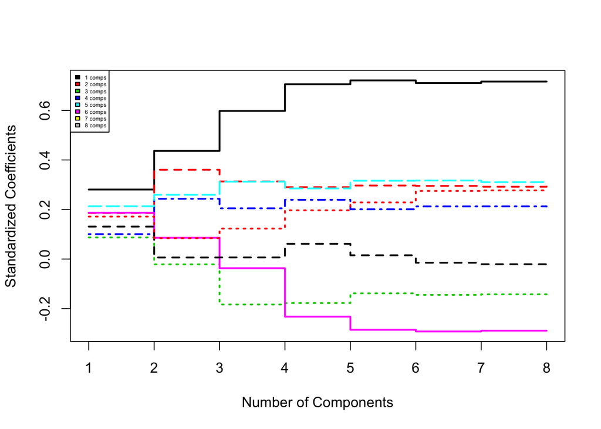

```r
matplot(t(plsr_coefs), type= 's', lwd = 2, xlab = "Number of Components", ylab = "Standardized Coefficients")
legend("topleft", colnames(plsr_coefs),col=seq_len(ncol(plsr_coefs)),cex=0.4,fill=seq_len(ncol(plsr_coefs)))
```

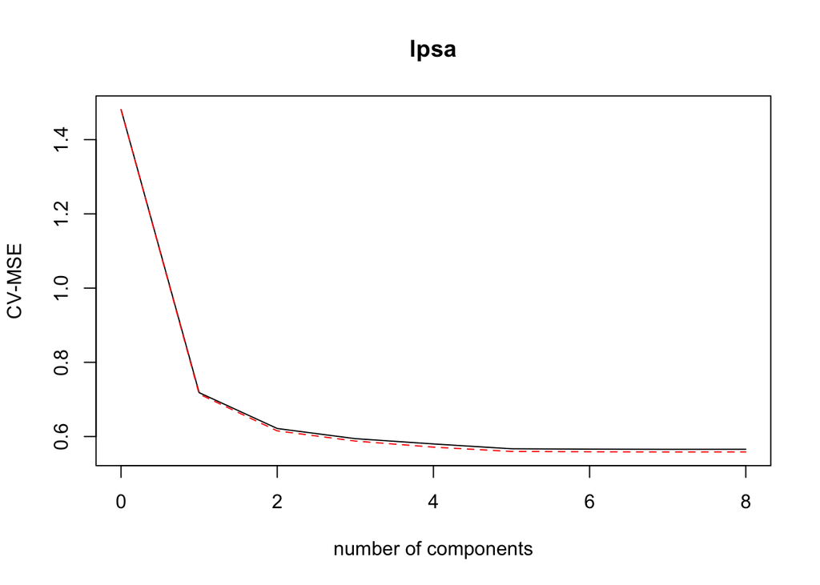

```r
validationplot(plsr_model, val.type = "MSEP", ylab = "CV-MSE")
```

## RR and Lasso (40 pts)

```r
set.seed(10)

# Fitting the model (Ridge: Alpha = 0)
ridgecv <- cv.glmnet(as.matrix(train_stan[,-9]), train_stan$lpsa , alpha = 0)

ridgecv
```

[output not shown]

[output cut: 209 more lines]

```r
coef(ridgecv, s = "lambda.min")
```

```
## 9 x 1 sparse Matrix of class "dgCMatrix"
##                       1
## (Intercept)  2.45234509
## lcavol       0.60438317
## lweight      0.28576500
## age         -0.10858418
## lbph         0.20096586
## svi          0.28336365
## lcp         -0.15469409
## gleason      0.01414138
## pgg45        0.20305366
```

```r
opt_lambda <- ridgecv$lambda.min
opt_lambda
```

```
## [1] 0.09645702
```

```r
# Q  lambda.min.ratio = opt_lambda


ridge <- glmnet(as.matrix(train_stan[,-9]), train_stan$lpsa , alpha = 0, lambda.min.ratio = opt_lambda)

ridge <- glmnet(as.matrix(train_stan[,-9]), train_stan$lpsa , alpha = 0, lambda = opt_lambda)



# Q is summary enough???
summary(ridge)
```

```
##           Length Class     Mode
## a0        1      -none-    numeric
## beta      8      dgCMatrix S4
## df        1      -none-    numeric
## dim       2      -none-    numeric
## lambda    1      -none-    numeric
## dev.ratio 1      -none-    numeric
## nulldev   1      -none-    numeric
## npasses   1      -none-    numeric
## jerr      1      -none-    numeric
## offset    1      -none-    logical
## call      5      -none-    call
## nobs      1      -none-    numeric
```

```r
# Q :  ridge.coef gives the best model's coefficients????


coef(ridgecv, s = ridgecv$lambda.min)
```

```
## 9 x 1 sparse Matrix of class "dgCMatrix"
##                       1
## (Intercept)  2.45234509
## lcavol       0.60438317
## lweight      0.28576500
## age         -0.10858418
## lbph         0.20096586
## svi          0.28336365
## lcp         -0.15469409
## gleason      0.01414138
## pgg45        0.20305366
```

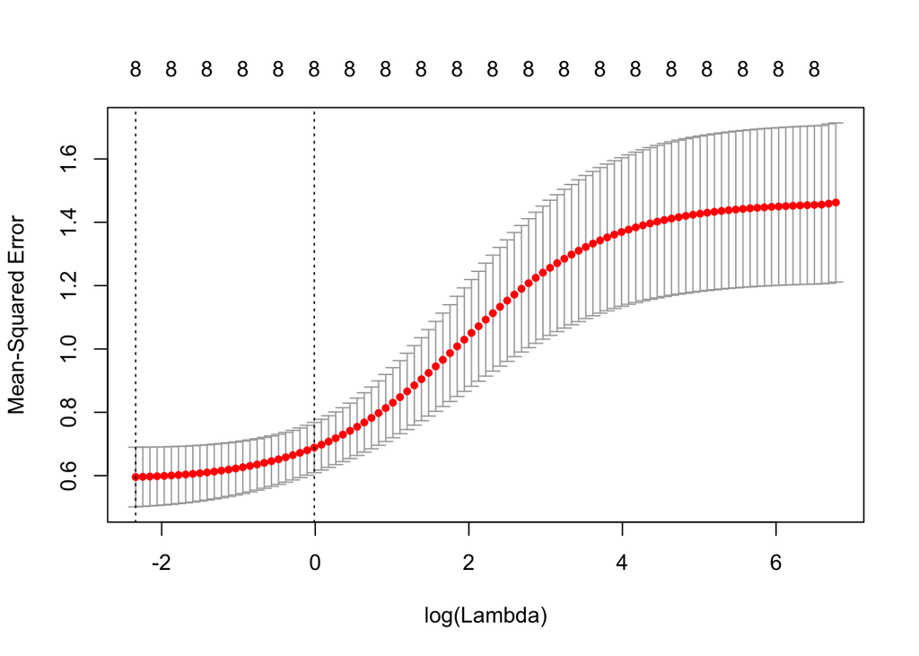

```r
plot.cv.glmnet(ridgecv)
```

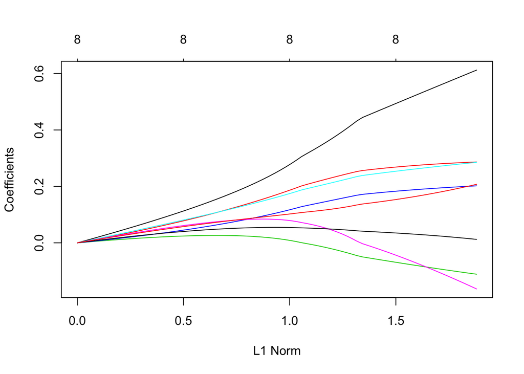

```r
#   Q :    ???? straight?

ridge <- glmnet(as.matrix(train_stan[,-9]), train_stan$lpsa , alpha = 0)


plot.glmnet(ridge)
```

```r
set.seed(10)
# Fitting the model (Lasso: Alpha = 1)


lassocv <- cv.glmnet(as.matrix(train_stan[,-9]), train_stan$lpsa , alpha = 1)

lassocv
```

[output not shown]

[output cut: 150 more lines]

```r
opt_lambda <- lassocv$lambda.min
opt_lambda
```

```
## [1] 0.007644054
```

```r
lasso <- glmnet(as.matrix(train_stan[,-9]), train_stan$lpsa , alpha = 1, lambda.min.ratio = opt_lambda)

lasso <- glmnet(as.matrix(train_stan[,-9]), train_stan$lpsa , alpha = 1, lambda= opt_lambda)


lasso
```

```
##
## Call:  glmnet(x = as.matrix(train_stan[, -9]), y = train_stan$lpsa,      alpha = 1, lambda = opt_lambda)
##
##      Df   %Dev   Lambda
## [1,]  7 0.6935 0.007644
```

```r
coef(lassocv, s = "lambda.min")
```

```
## 9 x 1 sparse Matrix of class "dgCMatrix"
##                      1
## (Intercept)  2.4523451
## lcavol       0.6918697
## lweight      0.2887031
## age         -0.1268621
## lbph         0.2033674
## svi          0.2940763
## lcp         -0.2389979
## gleason      .
## pgg45        0.2357199
```

```r
coef(lasso, s = "lambda.min")
```

```
## 9 x 1 sparse Matrix of class "dgCMatrix"
##                      1
## (Intercept)  2.4523451
## lcavol       0.6919179
## lweight      0.2887836
## age         -0.1269113
## lbph         0.2033150
## svi          0.2940639
## lcp         -0.2393184
## gleason      .
## pgg45        0.2359208
```

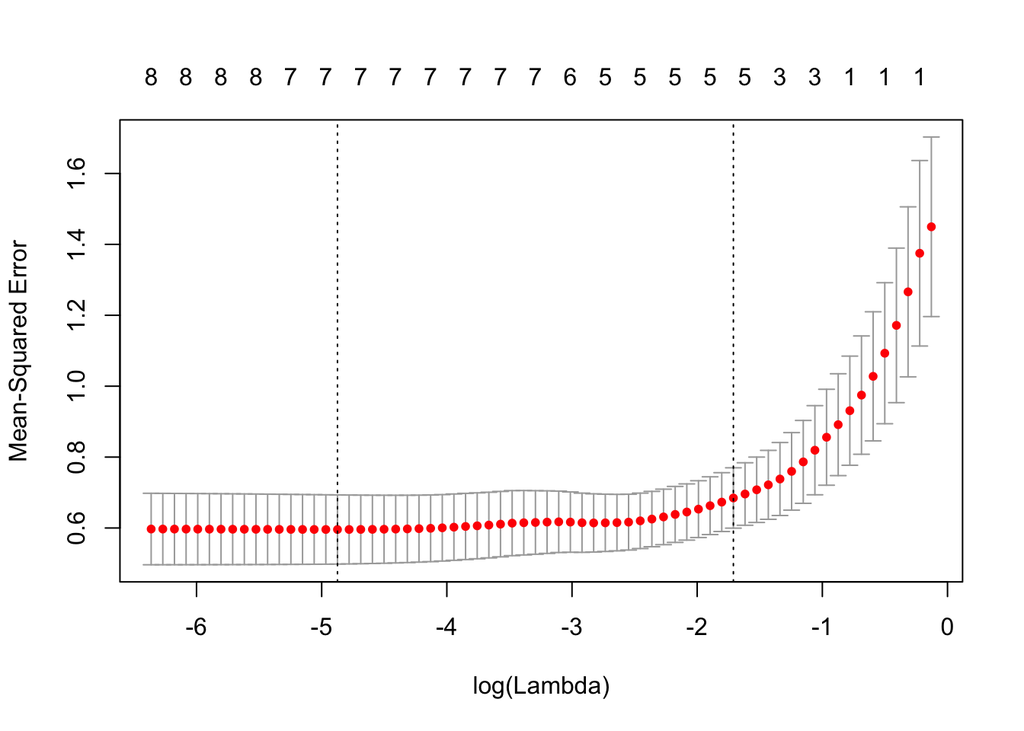

```r
plot.cv.glmnet(lassocv)
```

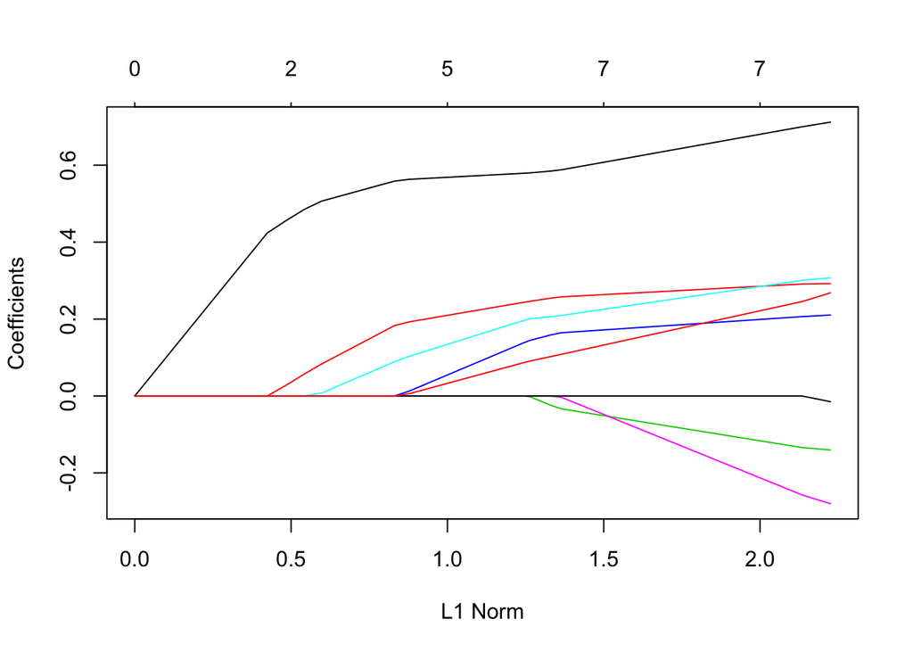

```r
lasso <- glmnet(as.matrix(train_stan[,-9]), train_stan$lpsa , alpha = 1)


plot.glmnet(lasso)
```

## Model Selection (20 pts)

```r
subset.coef <- coef(subset, minsubset)

#  c(coef(subset, minsubset), rep(NA,6))

ridge.coef <- (coef(ridgecv, s = ridgecv$lambda.1se))[1:9]
# Q :  s = labmda.min?
# or coef(ridgecv)


lasso.coef <- (coef(lassocv, s = lassocv$lambda.1se))[1:9]




# don't recycle
# Q PCR, PLS intercept coefficient needed


table <- cbind(LS = lsfit$coefficients,
               Best_Subset = c(subset.coef, rep(0, 6)),
              Ridge = ridge.coef , Lasso = lasso.coef, PCR =  coef(pcr_model, intercept = T), PLS = coef(plsr_model, intercept = T))

table
```

```
##                      LS Best_Subset        Ridge      Lasso         PCR
## (Intercept)  2.45234509   2.4523451  2.452345085 2.45234509  2.45234509
## lcavol       0.71640701   0.7798589  0.317607465 0.56536414  0.71640701
## lweight      0.29264240   0.3519101  0.207749630 0.19936439  0.29264240
## age         -0.14254963   0.0000000 -0.003245594 0.00000000 -0.14254963
## lbph         0.21200760   0.0000000  0.132737031 0.02917609  0.21200760
## svi          0.30961953   0.0000000  0.192527220 0.11532140  0.30961953
## lcp         -0.28900562   0.0000000  0.067982376 0.00000000 -0.28900562
## gleason     -0.02091352   0.0000000  0.052456497 0.00000000 -0.02091352
## pgg45        0.27734595   0.0000000  0.109563765 0.01647872  0.27734595
##                     PLS
## (Intercept)  2.45234509
## lcavol       0.71640701
## lweight      0.29264240
## age         -0.14254963
## lbph         0.21200760
## svi          0.30961953
## lcp         -0.28900562
## gleason     -0.02091352
## pgg45        0.27734595
```

```r
y <- test[,9]
X <- as.data.frame(scale(test[,-9]))

LSmse <- mean((predict(lsfit, X) - y)^2)
# why so huge?
LSmse
```

```
## [1] 0.5491941
```

```r
# Q : what's wrong??
#subsetmse <- mean(summary(subset)$rss^2)
#subset coefficients are the same as the OLS regression coefficients with the selected variable
subset_lm <- lm(lpsa ~ lcavol + lweight, data = train_stan)
subsetmse <- mean((predict(subset_lm, X) - y)^2)
subsetmse
```

```
## [1] 0.5483947
```

```r
#yhat <- as.matrix(cbind(1,test[,c(1,2)])) %*% as.matrix(subset_coef)
#  predict(subset_lm, test)  give the same results so it should be correct.
#head(yhat)



#ridgecv <- cv.glmnet(as.matrix(train_stan[,-9]), train_stan$lpsa , alpha = 0)
#opt_lambda <- ridgecv$lambda.min

# Q  lambda.min.ratio = opt_lambda
#ridge <- glmnet(as.matrix(train_stan[,-9]), train_stan$lpsa , alpha = 0, lambda.min.ratio = opt_lambda)



#ridgemse <- min(ridgecv$cvm)
ridgemse <- mean((predict(ridgecv, as.matrix(X), s = "lambda.min") - y)^2)

ridgemse
```

```
## [1] 0.5171794
```

```r
#lassomse <- min(lassocv$cvm)
lassomse <- mean((predict(lassocv, as.matrix(X), s = "lambda.min") - y)^2)

lassomse
```

```
## [1] 0.5304655
```

```r
#pcrmse <- mean(pcr_model$residuals^2)
pcrmse <- mean((predict(pcr_model, as.matrix(X), s = "lambda.min") - y)^2)
pcrmse
```

```
## [1] 0.5735587
```

```r
#plsmse <- mean(plsr_model$residuals^2)
plsmse <- mean((predict(plsr_model, as.matrix(X), s = "lambda.min") - y)^2)
plsmse
```

```
## [1] 0.5416171
```

```r
Test_Error <- c(LSmse, subsetmse, ridgemse, lassomse, pcrmse, plsmse )

Test_Error
```

```
## [1] 0.5491941 0.5483947 0.5171794 0.5304655 0.5735587 0.5416171
```

```r
table <- rbind(table, Test_Error)

table
```

```
##                      LS Best_Subset        Ridge      Lasso         PCR
## (Intercept)  2.45234509   2.4523451  2.452345085 2.45234509  2.45234509
## lcavol       0.71640701   0.7798589  0.317607465 0.56536414  0.71640701
## lweight      0.29264240   0.3519101  0.207749630 0.19936439  0.29264240
## age         -0.14254963   0.0000000 -0.003245594 0.00000000 -0.14254963
## lbph         0.21200760   0.0000000  0.132737031 0.02917609  0.21200760
## svi          0.30961953   0.0000000  0.192527220 0.11532140  0.30961953
## lcp         -0.28900562   0.0000000  0.067982376 0.00000000 -0.28900562
## gleason     -0.02091352   0.0000000  0.052456497 0.00000000 -0.02091352
## pgg45        0.27734595   0.0000000  0.109563765 0.01647872  0.27734595
## Test_Error   0.54919414   0.5483947  0.517179403 0.53046551  0.57355874
##                     PLS
## (Intercept)  2.45234509
## lcavol       0.71640701
## lweight      0.29264240
## age         -0.14254963
## lbph         0.21200760
## svi          0.30961953
## lcp         -0.28900562
## gleason     -0.02091352
## pgg45        0.27734595
## Test_Error   0.54161713
```

```r
cat("Best model is ", colnames(table)[which.min(Test_Error)])
```

```
## Best model is  Ridge
```